# Solutions to mid-term exam (ds4psy)

Hansjörg Neth, SPDS, uni.kn

2018 06 04

# Introduction

This file contains possible solutions to the **mid-term exam** (on June 4, 2018).

This exam contains a total of **6 tasks** and a maximum score of **50 points**.

## Course coordinates

- Course [Data Science for Psychologists](http://rpository.com/ds4psy/) (ds4psy).
- Taught at the [University of Konstanz](https://www.uni-konstanz.de/) by [Hansjörg Neth](http://neth.de/) (h.neth@uni.kn, [SPDS](https://www.spds.uni-konstanz.de/), office D507).
- Spring/summer 2018: Mondays, 13:30–15:00, C511 (from 2018.04.16 to 2018.07.16)
- Links to [ZeUS](https://zeus.uni-konstanz.de:443/hioserver/pages/startFlow.xhtml?_flowId=showEvent-flow&unitId=5101&termYear=2018&termTypeValueId=1&navigationPosition=hisinoneLehrorganisation,examEventOverviewOwn) and [Ilias](https://ilias.uni-konstanz.de/ilias/goto_ilias_uni_crs_758039.html)

## Preparation and response format

**0.** Please answer the following questions by creating a single R script (or an R-Markdown file `.Rmd`) that contains all your code and answers and meets the following criteria:

- *Layout issues*:
  1. Include a header that contains your *name*, *student ID*, this *course*, and today’s *date*.
  2. Load the R packages of the `tidyverse`.
  3. Structure your file clearly by *labeling* the current task (e.g., `# Task 1: -----`) and subtask (e.g., `# (a) ...:`) and by *leaving blank lines* between all tasks and subtasks.

  Here’s a layout template that you can copy and adapt:

```r
## Mid-term exam  | Data science for psychologists (Summer 2018)
## Name: ... | Student ID: ...
## 2018 06 04
## ~~~~~~~~~~~~~~~~~~~~~~~~~~~~~~~~~~~~~~~~~~~~~~~~~~~~~~~~~ ##

## Preparations: -----

library(tidyverse)


## Task 1: -----

## (a) Saving and inspecting data:
sp <- as_tibble(sleep)
dim(sp)

## Answer: The sleep data contains 20 rows and 3 columns.

## (b): ...
## ...


## Task X: -----
## (a) ...

## ~~~~~~~~~~~~~~~~~~~~~~~~~~~~~~~~~~~~~~~~~~~~~~~~~~~~~~~~~ ##
## End of file. -----
```

- Save your script (regularly) as `Lastname_Firstname_midTerm_180604.R` (replacing `Lastname` and `Firstname` by your names).
- When asked for numbers or interpretations, include *short answers as comments* in your script. However, when asked for quantitative summaries containing more than 2 numbers (e.g., descriptive statistics of a dataset) simply print your results (e.g., the output of a `dplyr` pipe) in your code.
- Submit your script by email (as an attachment) to h.neth@uni.kn by 15:15 (today).

# Task 1: Time to sleep

The `sleep` data (contained in R datasets) shows the effect of 2 sleep-promoting drugs (as an increase in hours of sleep compared to a control group) for 10 patients.

**1a.** Save the `sleep` data as a tibble `sp` and inspect its dimensions. (1 point)

**1b.** Use a `dplyr` pipe to compute the number of observations (rows) by group  
and key descriptives (their mean, median, and standard deviation). (2 points)

**1c.** Use `ggplot` to create a graph that shows the medians and raw values of `extra` sleep time by `group`. (2 points)

**Hints:** Use 2 different geoms to show both medians and raw values in the same plot. The order of layers is determined by the order of geom commands.

**1d.** Reformat the `sleep` data in `sp` so that the 2 groups appear in 2 lines (rows) and 10 subject IDs as 10 columns. (1 point)

**Hints:** This implies using the `tidyr::spread` command to change a long dataset into a wider format.

```r
# ?datasets::sleep

# (a) Save data as tibble and inspect:
sp <- as_tibble(sleep)
sp # => 20 cases (rows) x 3 variables (columns)
```

```
#> # A tibble: 20 x 3
#>     extra group ID
#>     <dbl> <fct> <fct>
#>  1  0.700 1     1
#>  2 -1.60  1     2
#>  3 -0.200 1     3
#>  4 -1.20  1     4
#>  5 -0.100 1     5
#>  6  3.40  1     6
#>  7  3.70  1     7
#>  8  0.800 1     8
#>  9  0     1     9
#> 10  2.00  1     10
#> 11  1.90  2     1
#> 12  0.800 2     2
#> 13  1.10  2     3
#> 14  0.100 2     4
#> 15 -0.100 2     5
#> 16  4.40  2     6
#> 17  5.50  2     7
#> 18  1.60  2     8
#> 19  4.60  2     9
#> 20  3.40  2     10
```

```r
# (b) Compute the number of observations and descriptives of extra time by group:
sp %>%
  group_by(group) %>%
  summarize(n = n(),
            md = median(extra),
            mn = mean(extra),
            sd = sd(extra))
```

```
#> # A tibble: 2 x 5
#>   group     n    md    mn    sd
#>   <fct> <int> <dbl> <dbl> <dbl>
#> 1 1        10 0.350 0.750  1.79
#> 2 2        10 1.75  2.33   2.00
```

```r
# (c) Visualize the raw values and averages by group:
ggplot(sp, aes(x = group, y = extra)) +
  geom_boxplot(aes(fill = group)) +
  # geom_violin() +
  geom_point(aes(shape = group), size = 4, alpha = 2/3, position = "jitter") +
  ## Pimping plot:
  labs(title = "Extra sleep time by treatment group",
       x = "Treatment group", y = "Extra sleep time",
       caption = "Data from datasets::sleep.") +
  scale_fill_manual(values = c("gold1", "steelblue3")) +
  theme_bw()

# (d) Reformat data so that the 2 groups appear in 2 lines,
#     and 10 subject IDs as 10 columns:
sp %>%
  spread(key = ID, value = extra)
```

```
#> # A tibble: 2 x 11
#>   group   `1`    `2`    `3`    `4`    `5`   `6`   `7`   `8`   `9`  `10`
#> * <fct> <dbl>  <dbl>  <dbl>  <dbl>  <dbl> <dbl> <dbl> <dbl> <dbl> <dbl>
#> 1 1     0.700 -1.60  -0.200 -1.20  -0.100  3.40  3.70 0.800  0     2.00
#> 2 2     1.90   0.800  1.10   0.100 -0.100  4.40  5.50 1.60   4.60  3.40
```

```r
pt <- pt + 6  # increment point total
```

[figure not shown]

# Task 2: Party plots

The following table provides the percentage share of 2 major parties on the last 2 general elections of Germany (based on [this link](https://www.bundeswahlleiter.de/info/presse/mitteilungen/bundestagswahl-2017/34_17_endgueltiges_ergebnis.html)):

| Party: | Share 2013: | Share 2017: |
| --- | --- | --- |
| CDU/CSU | 41.5% | 33% |
| SPD | 25.7% | 20.5% |
| Others | `?` | `?` |

**2a.** Create a tibble `de` that contains this data and the missing (`?`) values for all other parties so that all shares of an election add up to 100%. (2 points)

**2b.** Convert your `de` table into a “tidy” table saved as `de_2`. (2 points)

**Hints:** Use `tidyr::gather` to list the values of all election results in 1 variable called `share` and make sure that `de_2` contains a separate variable (column) that specifies the election `year`.

**2c.** Visualize and contrast the election results by a bar chart that contains 2 bars (representing the 2 elections) and the party’s share of votes (as the proportions of each bar). (2 points)

**Hints:** As the data in `de_2` already contains the identity of the values which you want to plot, there is no need to count anything. Showing multiple values in one bar is called a “stack”.

```r
## (a) Create a tibble with the data:
de <- tibble(
    party = c("CDU/CSU", "SPD", "Others"),
    share_2013 = c((.341 + .074), .257, (1 - (.341 + .074) - .257)),
    share_2017 = c((.268 + .062), .205, (1 - (.268 + .062) - .205))
  )
de$party <- factor(de$party, levels = c("CDU/CSU", "SPD", "Others"))  # optional
de
```

```
#> # A tibble: 3 x 3
#>   party   share_2013 share_2017
#>   <fct>        <dbl>      <dbl>
#> 1 CDU/CSU      0.415      0.330
#> 2 SPD          0.257      0.205
#> 3 Others       0.328      0.465
```

```r
## Check that columns add to 100:
sum(de$share_2013)  # => 1 (qed)
```

```
#> [1] 1
```

```r
sum(de$share_2017)  # => 1 (qed)
```

```
#> [1] 1
```

```r
## (b) Converting de into a tidy data table:
de_2 <- de %>%
  gather(share_2013:share_2017, key = "election", value = "share") %>%
  separate(col = "election", into = c("dummy", "year")) %>%
  select(year, party, share)
de_2
```

```
#> # A tibble: 6 x 3
#>   year  party   share
#> * <chr> <fct>   <dbl>
#> 1 2013  CDU/CSU 0.415
#> 2 2013  SPD     0.257
#> 3 2013  Others  0.328
#> 4 2017  CDU/CSU 0.330
#> 5 2017  SPD     0.205
#> 6 2017  Others  0.465
```

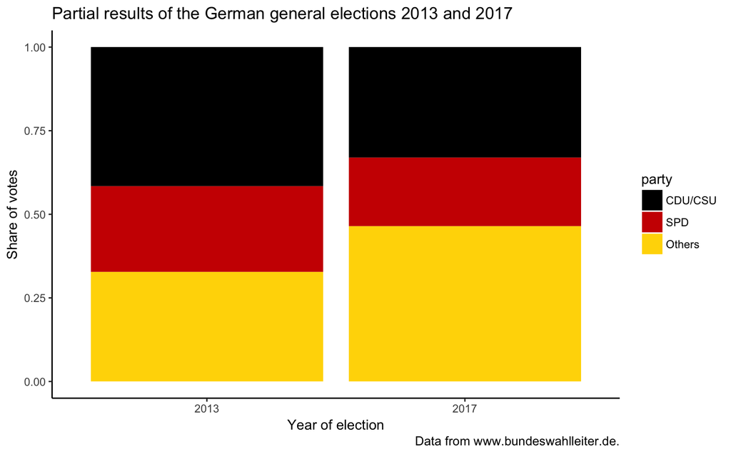

```r
## Note that year is of type character, which could be changed by:
# de_2$year <- parse_integer(de_2$year)

## (c) Bar chart showing proportions for each election:
ggplot(de_2, aes(x = year, y = share, fill = party)) +
  ## (A) 1 bar per election (position = "stack"):
  geom_bar(stat = "identity", position = "stack") +  # 1 bar per election
  ## (B) 3 bars per election (position = "dodge"):
  # geom_bar(stat = "identity", position = "dodge") +  # 3 bars next to each other
  ## Pimping plot:
  scale_fill_manual(values = c("black", "red3", "gold")) + # optional
  labs(title = "Partial results of the German general elections 2013 and 2017",
       x = "Year of election", y = "Share of votes",
       caption = "Data from www.bundeswahlleiter.de.") +
  theme_classic()

pt <- pt + 6  # increment point total
```